# The Presidency

POLS 2311: Government of the United States

## Agenda

- Presidential Powers
- The Evolution of the Presidency
- How Presidents Influence Policy
- Presidential Organization and Transition
- Presidential Elections
- Checks on Presidential Power

## Presidential Approval

[figure not shown]

# Presidential Power

## Article II Section 1

> *The executive Power shall be vested in a President of the United States of America*
- The presidency is the most *visible* position in the U.S. government
- The Founders accepted the need to empower a relatively strong and vigorous chief executive …
  - … but they also wanted this chief executive to be restrained by checks from the other branches of the federal government, as well as by the Constitution itself
- *The presidency is about the execution of the law*

## Presidents versus Prime Ministers

**U.S. Presidents**

- Often state government leaders, not members of Congress
- Gain support due to their “outsider” status
- Select cabinets from outside Congress

**Prime Ministers**

- Representative of the party in power
- Are often “insiders”
- Select cabinets from Parliament

## Divided and Unified Government

- Presidents have **no guaranteed legislative majority**
- **Divided government**: one party controls the White House, another controls one or both chambers of Congress
- **Unified government**: the same party controls the White House and both chambers
- Since 1952: at least 60% of congressional elections have produced divided government

## Energy in the Executive

[figure not shown]

## Energy in the Executive

### Hamilton, Federalist No. 70

> *Energy in the Executive is a leading character in the definition of good government. It is essential to the protection of the community against foreign attacks; it is not less essential to the steady administration of the laws; to the protection of property against those irregular and high-handed combinations which sometimes interrupt the ordinary course of justice; to the security of liberty against the enterprises and assaults of ambition, of faction, and of anarchy*

## Hamilton’s Ingredients of Energy

### Federalist No. 70

- **Unity**: a single executive, not a council or plural executive
  - *“Decision, activity, secrecy, and despatch will generally characterize the proceedings of one man”*
- **Duration**: a term long enough to act with firmness
- **Adequate support**: a salary Congress cannot cut to pressure the president
- **Competent powers**: veto, command of the military, appointments
- *But* energy must be safe: *“a due dependence on the people, a due responsibility”*

## Selection and Re-eligibility

### Federalist No. 68 and No. 72

**Fed. 68: Electoral College**

- Mix of popular choice and deliberative judgment by electors
- Guards against candidates with only *“talents for low intrigue, and the little arts of popularity”*

**Fed. 72: Re-election**

- Hamilton opposed term limits
- The chance to be re-elected gives presidents an incentive to perform well
- Barring re-election would waste experience in a crisis

## The Power of Commander in Chief

- Extends beyond military control
- Includes management of the economy and the direction of foreign affairs
- Grows more in wartime, but applies in peacetime too

## Article II, Section 2

### Expressed Powers of the Presidency

- Commander in Chief
- Grant pardons
- Treaties; *approved by two-thirds of the Senate*
- Appoint ambassadors, judges, and other officers *with advice and consent of the Senate*
- *Veto legislation* (Article I, Section 7)
- State of the Union (Section 3)

## Balance of Powers: Article II

**Unilateral Authority**

- Commander-in-chief
- Commission officers
- Grant pardons and reprieves (except impeachment)
- *Take Care Clause*

**Shared with the Senate**

- Make treaties
- Appoint ambassadors, judges, high officials

**Shared with Congress**

- Approve legislation

## Article II

### The *Take Care Clause*, Section 3

> *he shall take Care that the Laws be faithfully executed*
- Provides for the *implied powers* of the presidency
  - Military action
  - Domestic security
  - Executive agreements: Formal agreements negotiated with foreign governments
  - Executive privilege: The right to withhold certain communications from Congress or courts to protect confidential deliberations
  - *Executive orders*

## Executive Orders

- **Executive order**: a directive to federal agencies on how to interpret or carry out existing law
  - Legally binding on the executive branch
  - Cannot make new law or contradict a statute
- **Easy to reverse**: the next president can revoke them with the stroke of a pen
  - Schedule F: created by Trump (2020), revoked by Biden, reinstated by Trump (2025)
- **Checked by the courts**
  - EO 14160 sought to end birthright citizenship; blocked by courts and never took effect
  - *Trump v. Barbara* (2026): Supreme Court struck it down as unlawful

## Executive Orders

### Total Orders by President

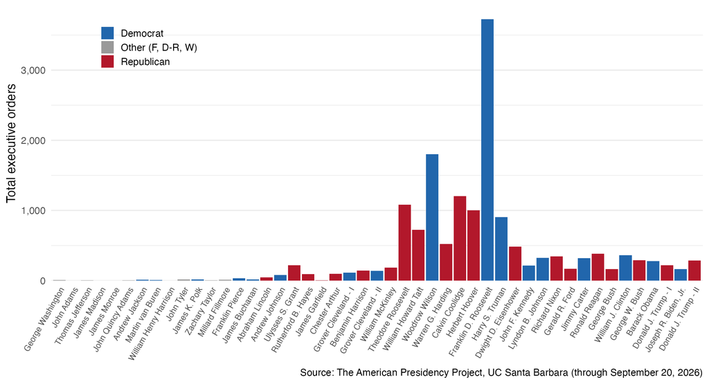

# The Evolution of the Presidency

## Founding Debates

- Delegates believed governing a large nation required a single president with significant power
- Some feared the presidency would become, in Edmund Randolph’s words, the “foetus of monarchy”
- The Framers positioned the president’s clearest constitutional authority over the military
- **Electoral College**: an indirect way of selecting the president
- **Term of office**: originally no term limits; presidents rarely sought more than two terms until FDR; the 22nd Amendment (1951) formally capped the office at two terms

## The 12th Amendment (1804)

- **Original design**: each elector cast two votes; the top vote-getter became president and the runner-up became vice president
- The rise of parties broke the system
  - **1796**: rivals Adams (president) and Jefferson (vice president) were elected together
  - **1800**: Jefferson and his running mate Aaron Burr tied, and the House needed 36 ballots to choose Jefferson
- **The fix**: electors cast separate votes for president and vice president
- A broader reform failed: Hamilton’s 1802 draft also required electors to be chosen by district, but only the separate-ballot provision survived

## From the First Presidents to the Modern Presidency

- **The first presidents**: prominent, but kept a modest office; distrusted political parties
- **The Jacksonians**: more contentious relationship with Congress; increased use of the veto power (Jackson vetoed 12 acts — more than all his predecessors combined)
- **The re-emergence of Congress**: Congress became the leading institution during a highly partisan era
- **The rise of the modern presidency**: initiates a policy agenda, oversees a robust staff, wields greater formal and informal power, and commands heightened visibility

[figure not shown]

*The first cabinet: Secretary of War Henry Knox, Secretary of State Thomas Jefferson, Attorney General Edmund Randolph, Secretary of the Treasury Alexander Hamilton, and President George Washington*

# How Presidents Influence Policy

## The Three Audiences

- **Other leaders**
- **Party leaders and activists**
- **The public**
  - Presidents communicate with the public to convert personal popularity into congressional support and to improve reelection chances

## Additional Tools of Influence

- **Veto message**: the president expresses to Congress the intention to veto legislation
- **Pocket veto**: a bill fails to become law because the president did not sign it within 10 days before Congress adjourns
- **Impoundment of funds**: refusal to spend congressionally appropriated funds
  - Impoundment was constrained by the *Impoundment Control Act* of 1974
- **Signing statements**: statements accompanying the signing of a bill, sometimes declaring part of the law unconstitutional

# Presidential Organization and Transition

## Presidential Organization

- **The White House Office**: the president’s closest personal staff
- **The Executive Office of the President** (established 1939): policy and management staff serving the presidency as an institution
- **The Cabinet**
- Independent agencies, commissions, and judgeships

## Presidential Organization

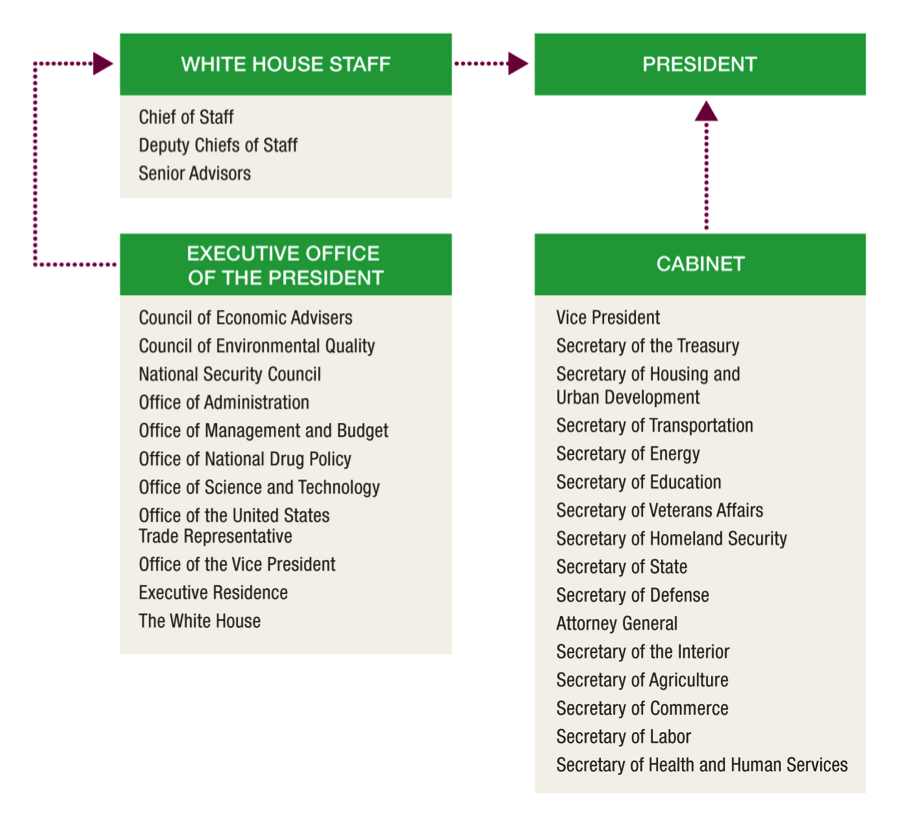

## Presidential Succession and Transition

- **The Succession Act of 1886**: designated the Secretary of State next in line after the vice president, followed by other cabinet officers by seniority
- **The 25th Amendment**: allows the vice president to serve as “acting president” if the president is disabled
- *Most* transitions of power have been peaceful: January 6, 2021

## Impeachment

- Article II, Section 4: officers “*shall be removed from Office on Impeachment for, and Conviction of, Treason, Bribery, or other high Crimes and Misdemeanors*”
- Only three presidents have ever been impeached, for a total of four times: Andrew Johnson (1868), Bill Clinton (1998), and Donald Trump (2019 and 2021)
- January 2021: the first time in U.S. history a president was impeached twice
- What counts as a “high Crime and Misdemeanor”? Readings range from a technical crime, to whatever the House judges sufficiently bad, to an *egregious abuse of distinctly presidential power*

# Presidential Elections

## The Constitution

- Thirty-five years of age
- Natural-born citizen
- Fourteen years a US resident
- Elected to a four-year term
- Limited to two-terms
  - Twenty-Second Amendment (1951)
- Electoral College

## The Process

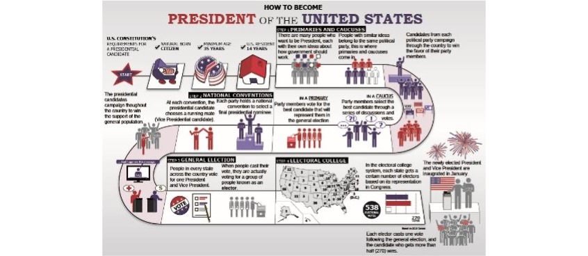

## The Electoral College

### Hamilton, Federalist No. 68

> *…the immediate election should be made by men most capable of analyzing the qualities adapted to the station, and acting under circumstances favorable to deliberation… A small number of persons, selected by their fellow-citizens from the general mass, will be most likely to possess the information and discernment requisite to such complicated investigations*

## Why an Electoral College?

- The Convention rejected two alternatives
  - **Selection by Congress**: would make the president dependent on the legislature
  - **Direct popular vote**: a large nation, voters with little information about distant candidates, and slave states that would lose the weight of the Three-Fifths Compromise
- The compromise served two purposes
  1. A **check on the people**: guard against a candidate with “talents for low intrigue, and the little arts of popularity”
  2. A **balance between small and large states**: every state gets at least three electors

## How the Electoral College Works

- **Electoral College**: the people chosen to cast each state’s votes in a presidential election
- Each state gets one elector for each senator and representative
  - D.C. gets 3 (23rd Amendment, 1961)
  - **538** total electors; **270** needed to win
- 48 states use **winner-take-all**; Maine and Nebraska award electors by congressional district
- Electors meet in state capitals in December; Congress counts the votes in January
- No majority? The **House** chooses among the top three, **one vote per state delegation**

## Not the Framers’ Electoral College

- Political parties emerged within five years of ratification
- By the early 1800s, electors **pledged their votes in advance**: party loyalists, not independent judges
- **12th Amendment (1804)**: separate ballots for president and vice president
- *The election of a President of the United States is no longer that process which the Constitution contemplated* (1816)

## Choosing Electors: Three Methods

- The Constitution lets each **state legislature** decide how electors are chosen
  - **Legislative appointment**: the legislature picks the electors
  - **District method**: each district chooses one elector
  - **Winner-take-all**: the statewide winner receives every elector
- States switched methods for **partisan advantage**, sometimes days before an election
  - Massachusetts changed its method seven times in the first ten elections
- By **1836**, all but one state had adopted winner-take-all

## The Electoral College Today

- **Short ballot** (after 1920): ballots list the candidates, not the electors — most voters never learn their electors’ names
- Parties choose their own slates of electors
- **Faithless electors**: most states require electors to vote for their party’s nominee
  - *Chiafalo v. Washington* (2020): states may enforce those pledges
- **Electoral Count Reform Act (2022)**: the vice president’s role in counting is purely ministerial; objections require one-fifth of each chamber

## Presidential Election 2024

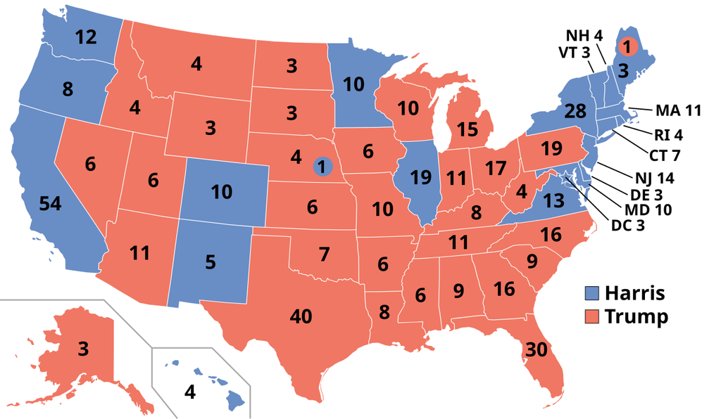

## Electoral College vs. Popular Vote

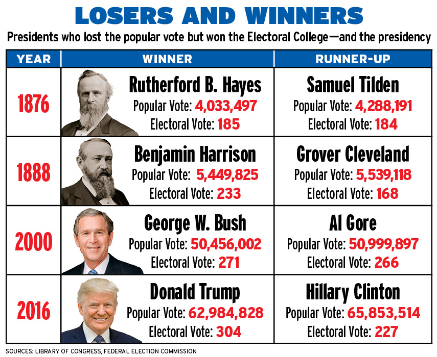

## Winner-Take-All and Swing States

- Winner-take-all makes most states **safe** for one party
- Campaigns concentrate on a handful of **battleground states**
  - 2024: Arizona, Georgia, Michigan, Nevada, North Carolina, Pennsylvania, Wisconsin
- Voters in safe states see few candidate visits and little advertising
- Small states are overrepresented: a Wyoming elector represents about one-quarter as many people as a California elector

## Debating the Electoral College

**Defenders**

- Preserves the federal character of the Union
- Forces candidates to build broad, geographically distributed coalitions
- Contains disputes and recounts within single states

**Critics**

- Presidents can lose the popular vote
- Votes count unequally across states
- Campaigns ignore safe states
- Robert Dahl: one of the Constitution’s remaining **democratic deficiencies**

# Checks on Presidential Power

## Checks on the Presidency

- Congress can override vetoes (2/3 majority, both chambers)
- The Senate must confirm treaties (2/3) and major appointments (majority)
- Congress can impeach and remove the president
- Courts review executive actions for constitutional and statutory compliance

## *Trump v. United States* (2024): Presidential Immunity

- Arose from Special Counsel Jack Smith’s indictment of former President Trump over efforts to overturn the 2020 election and the January 6, 2021 attack on the Capitol
- Chief Justice Roberts’s majority opinion established a **three-tier immunity framework** for former presidents

## The Three Tiers of Immunity

- **Absolute immunity** for acts within the president’s core constitutional powers — e.g., the pardon power, the veto, recognizing ambassadors, appointments
- **Presumptive immunity** for other official acts — prosecutors can only overcome this by showing prosecution poses no danger to executive functioning
- **No immunity** for unofficial (private) acts

## Dissent: “A King Above the Law”?

- Justice Sotomayor: the ruling has no textual or historical basis — the framers gave members of Congress narrow immunity (the Speech or Debate Clause) but deliberately gave presidents none
- The **Impeachment Judgment Clause** (Article I, Section 3) presupposes a president *can* face criminal prosecution after impeachment
- Sotomayor warns the ruling’s broad view of “official” conduct makes “the President… a king above the law”
- Justice Jackson (separate dissent): the ruling “unilaterally altered the balance of power” among the branches

## Immunity in a Broader Context

- Scholars group *Trump v. United States* with other 2020s Supreme Court decisions expanding presidential power at Congress’s expense
- The end of *Chevron* deference
- *Trump v. Slaughter* (2026): overruled *Humphrey’s Executor v. United States* (1935), constitutionalizing the **Unitary Executive Theory** — agency officials exercising “executive power” may be removed by the president at will

## How Powerful Is the President Today?

- Presidents hold significant constitutional and political power, and are expected to lead the country and set the national policy agenda